# FACTORES DE INCIDENCIA EN SINIESTROS VIALES EN EL DEPARTAMENTO PARANÁ, ENTRE RÍOS

Alejandro Rouiller – Zacarías Ojeda – Melisa Fernández

16/10/2019

# Motivación

## Motivación

- Costos humanos, materiales, psicológicos
- Pérdidas personales, familiares, como sociedad
- Agencia Nacional de Seguridad Vial adhirió al Decenio para la Acción para la Seguridad Vial 2011-2020 (disposición 92/2011)

# Metodología

## Metodología

- Recolección de datos
- Carga manual
- Procesamiento

## Objetivo

- Analizar los siniestros viales registrados en el departamento de Paraná durante el primer trimestre de 2018 por la División de Accidentología de la Dirección Criminalística de la Policía de Entre Ríos.
- Determinar asociaciones entre variables para predecir la severidad de los siniestros.

## Definiciones

### **Siniestros leves**

No hubo ninguna persona involucrada en el siniestro que fuera un herido grave.

### **Siniestros graves**

Al menos una persona en el siniestro resulto ser un *herido grave*.

### **Herido grave**

Cualquier persona hospitalizada durante más de 24 horas.

### **Unidad de trafico**

Cualquiera de las partes involucradas en el siniestros.

## Variables de estudio

- Día: día de la semana
- Rango horario: día / noche
- Clase de día: laborable/fin de semana
- Franja horaria: mañana (6-13), tarde (14-21) y noche (22-5)
- Comisaria que interviene
- Geolocalización
- Unidades de tránsito: auto/auto, moto/auto, auto/peatón, moto/peatón, etc.
- Condiciones climáticas: despejado/nublado/niebla/llovizna/lluvioso/granizo
- Viento: suave/moderado/fuerte/temporal
- Visibilidad: buena/reducida
- Iluminación: natural/ artificial (buena-regular-mala)/zona de penumbras/nula

## Variables de estudio …

- Calzada: asfalto/H° A°/tierra suelta/tierra compacta/ripio/arena/pasto corto/pasto largo
- Estado de la calzada: bueno/regular/malo
- Estado del suelo: limpio/sucio/seco/húmedo/charcos de agua
- Señalización vial si/no horizontal/vertical/ sin incidencia
- Semáforos: si/no funciona si/no Estado: intermitente/continuo
- Edad del conductor
- Tipo de siniestro: leve/grave

## Variables de estudio …

- Causalidad
- Marca de vehículo
- Modelo de vehículo
- Año de vehículo
- Licencia de conducir: si/no
- Informe requerido fiscalía: si/no

# Análisis descriptivo

## Análisis de las lesiones

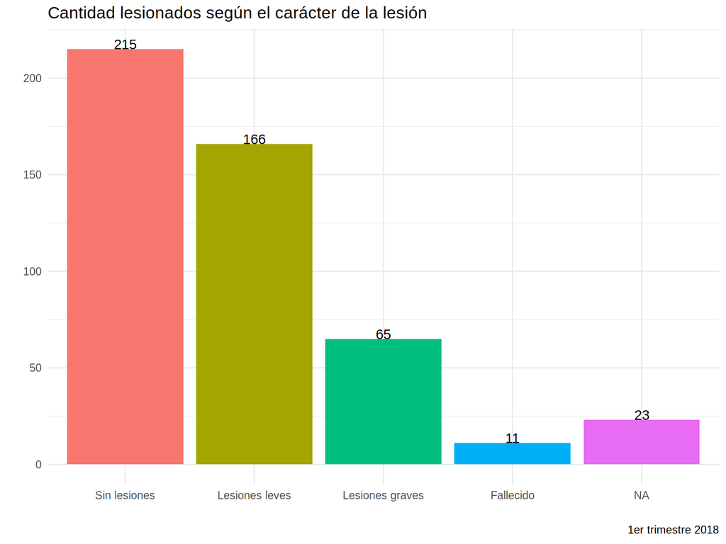

## Analisis de los siniestros en base a las lesiones

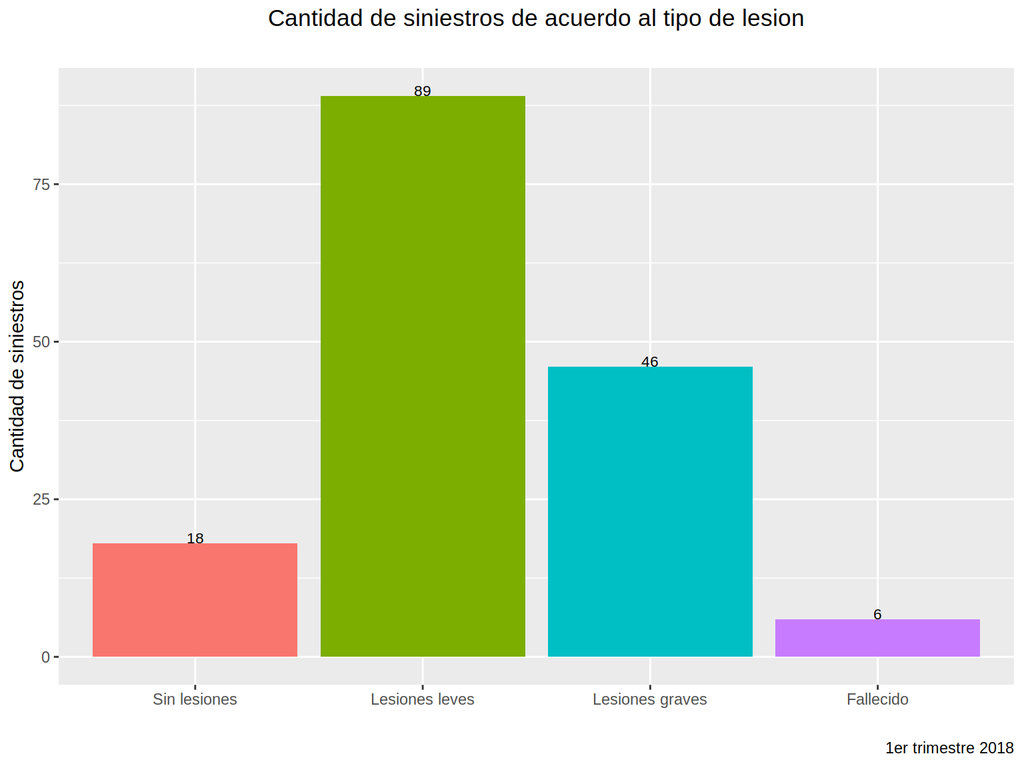

## Cantidad de unidades de transito involucradas

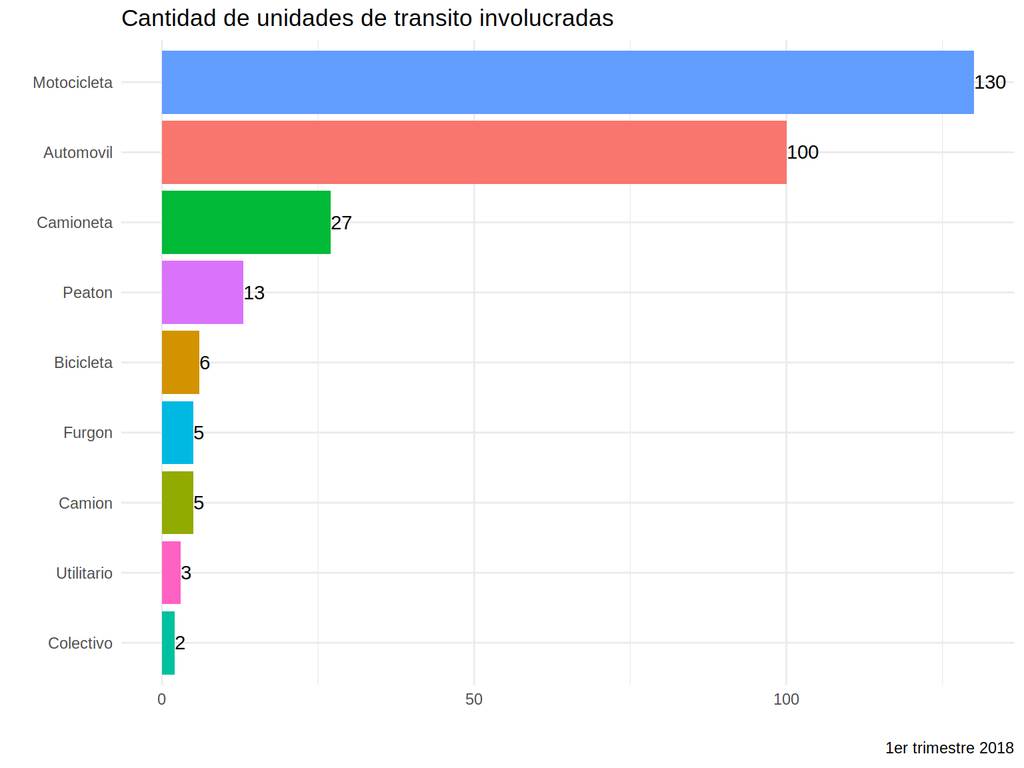

## Siniestros de acuerdo al tipo de unidades de transito involucradas

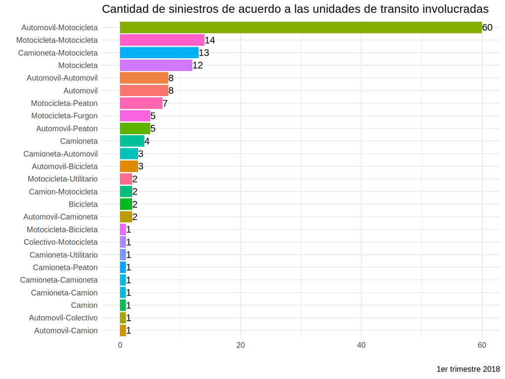

## Siniestros según la hora del día

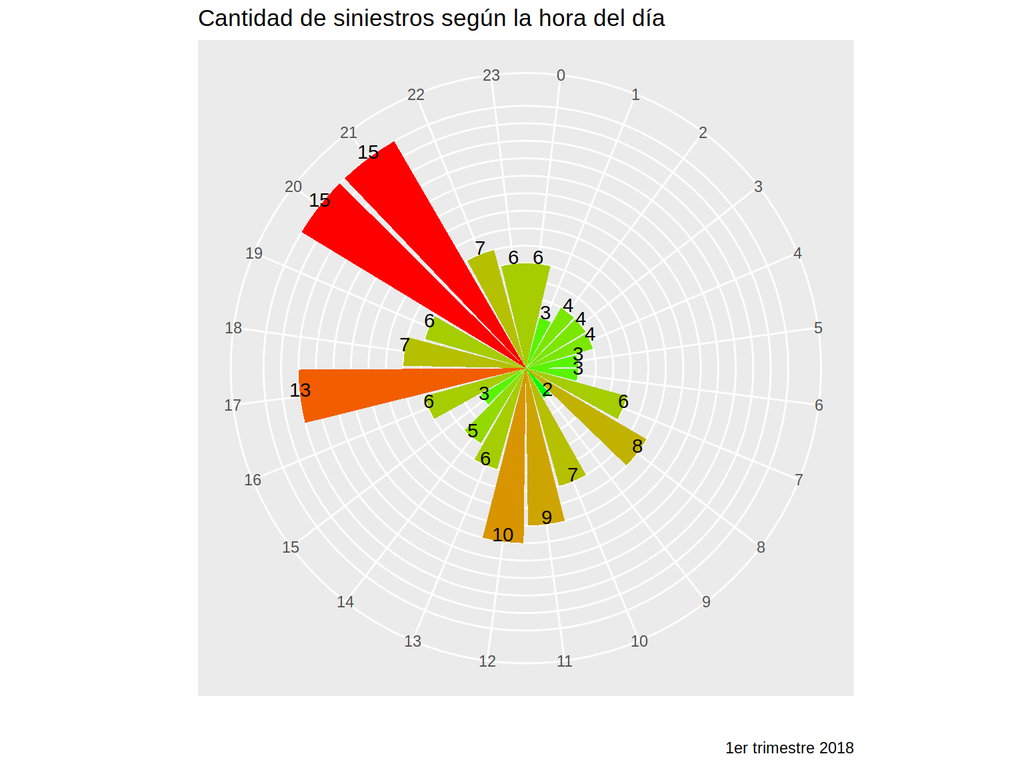

## Siniestros según la hora del día - Lunes a viernes vs fines de semana

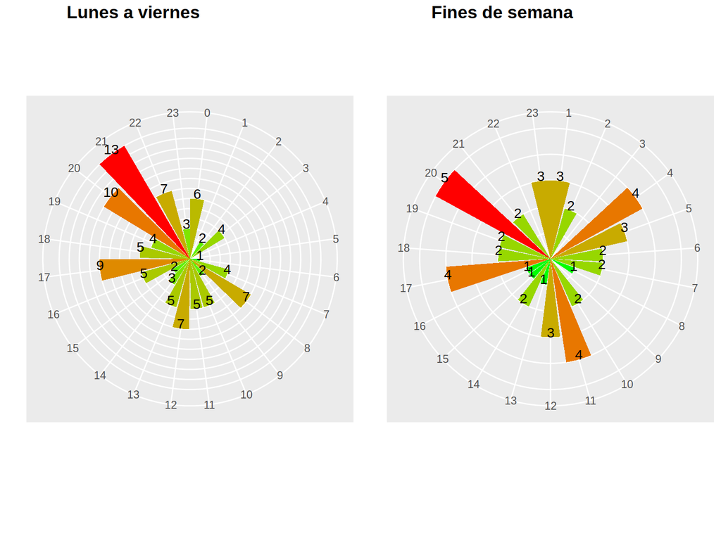

## Analisis de la causalidad

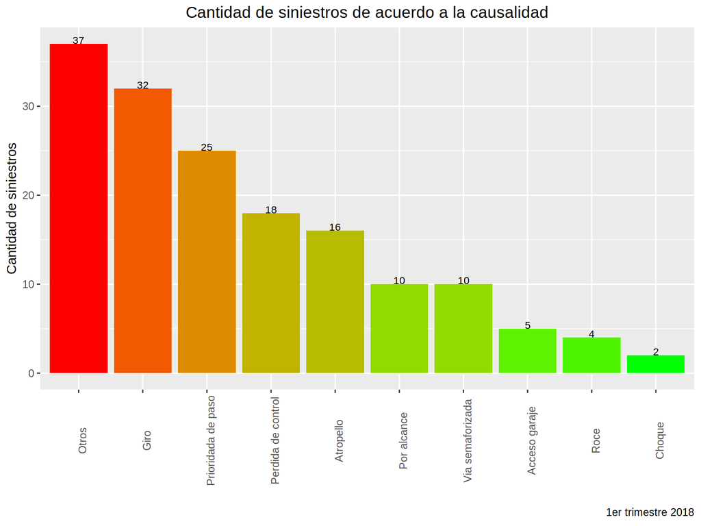

## Edad de los conductores

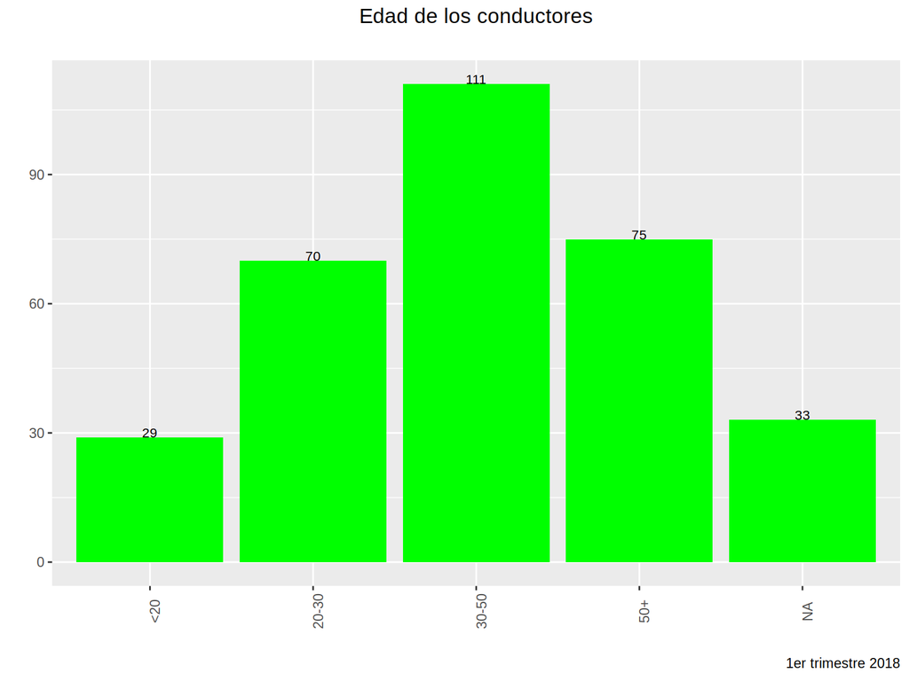

## Siniestros de acuerdo al tipo de lesión

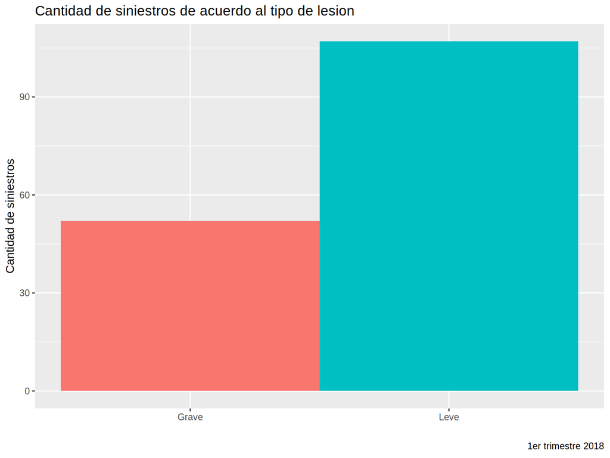

# Análisis bivariado

## Resumen estadísticos de variables consideradas

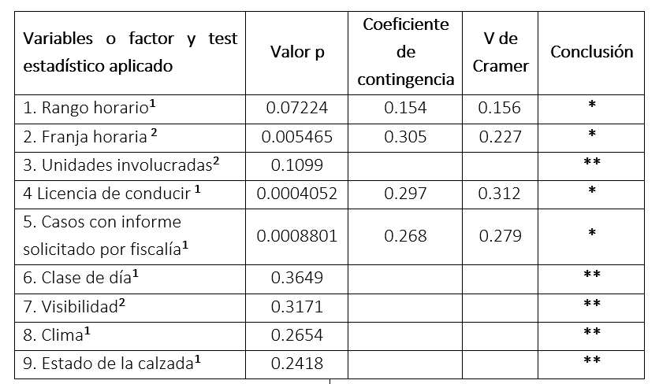

## Tipo de lesion (binarizada) vs dia/noche

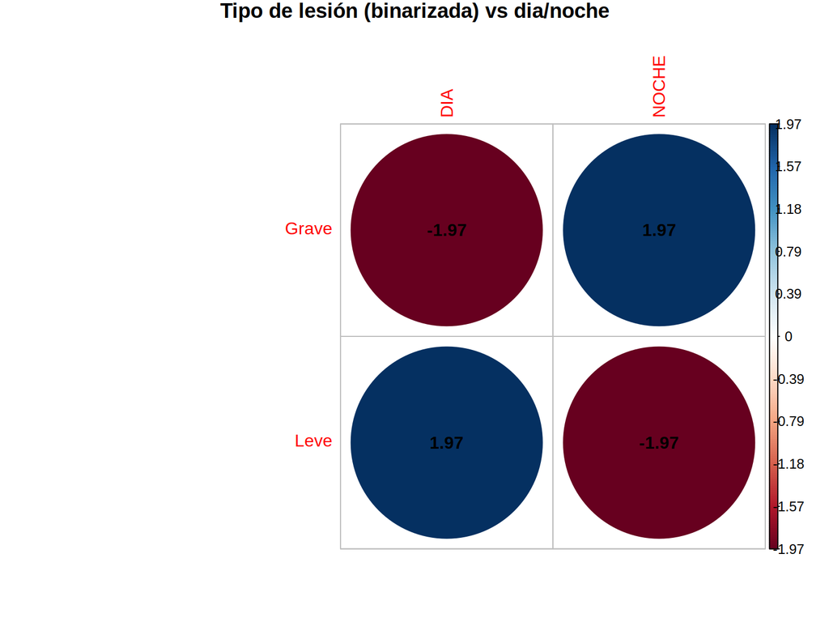

## Momento del dia (mañana/tarde/noche) vs tipo de lesion

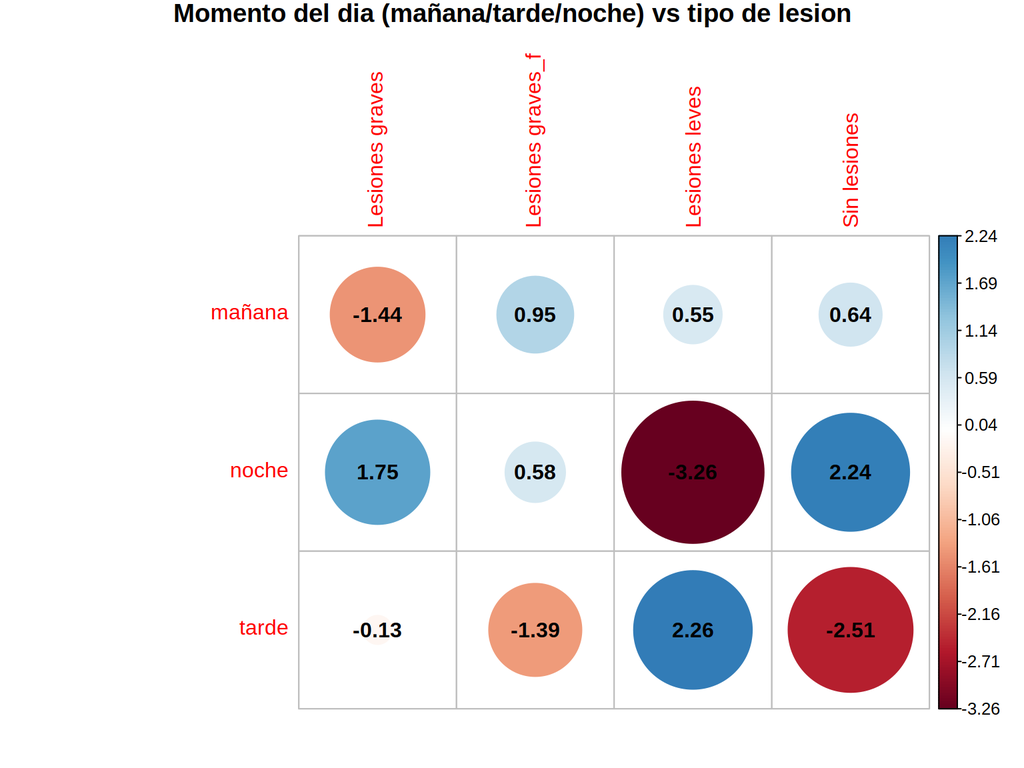

## Posesión de carnet vs tipo de lesion

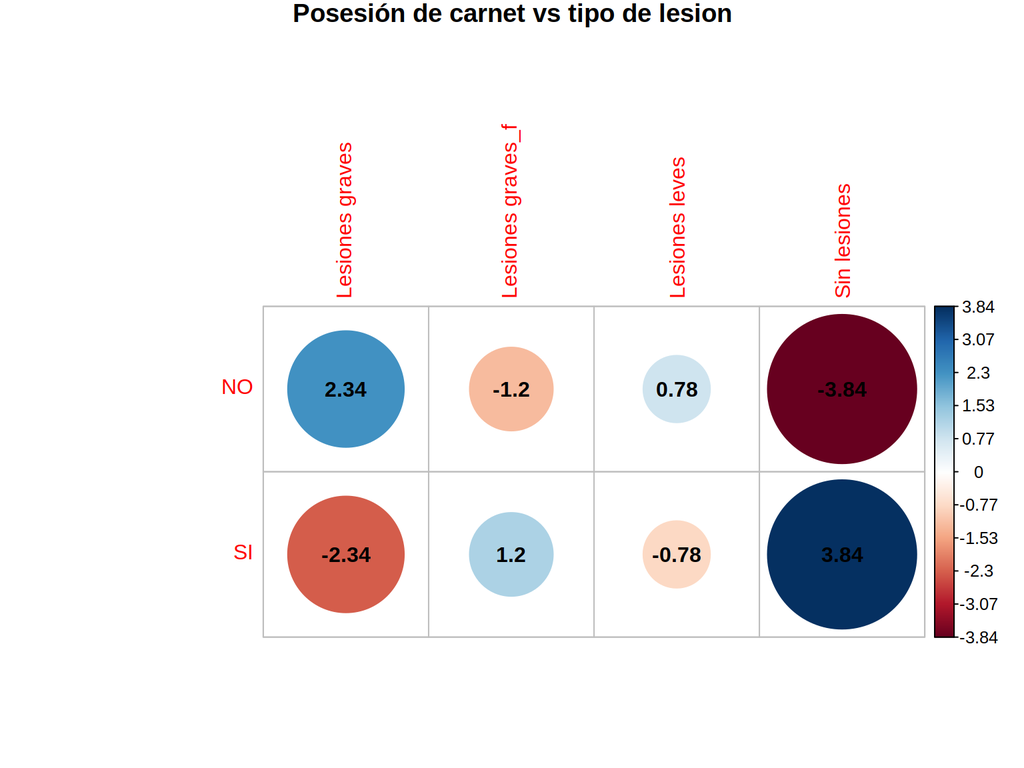

# Análisis multivariado

## MCA porcentaje explicado de la varianza

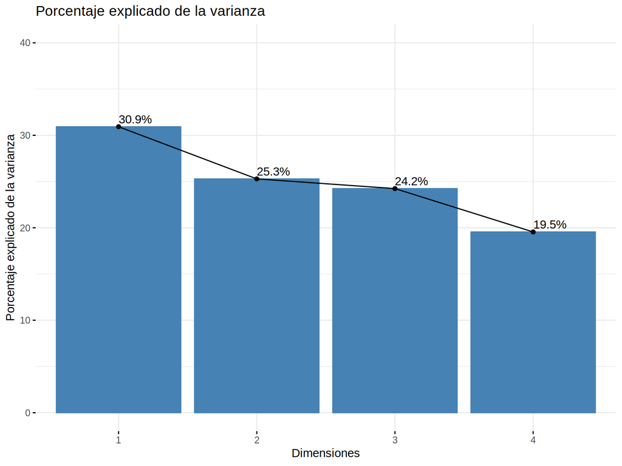

## MCA variables

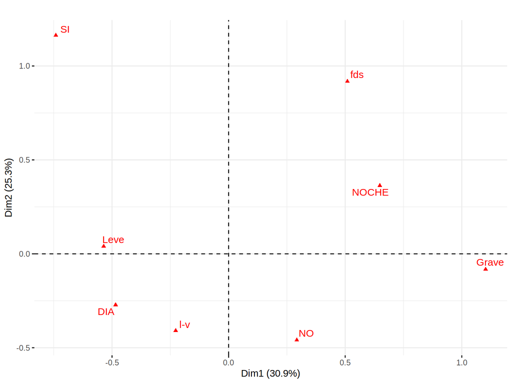

## MCA biplot

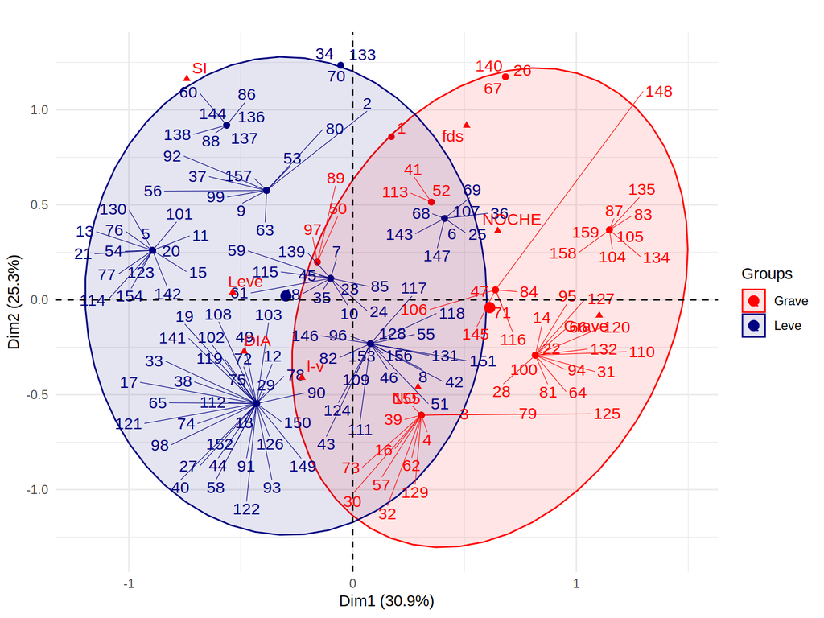

# Análisis geolocalización

## Por categoría de siniestro

[interactive chart not shown]

## Por rango horario

[interactive chart not shown]